# MAST32001 Computational Statistics

Author

Zhi Zhou

Published

September 20, 2026

```r
knitr::opts_chunk$set(
  echo = TRUE,
  warning = FALSE,
  message = FALSE,
  fig.width = 5.5,
  fig.height = 3.8,
  fig.align = "center",
  dpi = 300
)
library(ggplot2)
theme_set(
  theme_classic(base_size = 12, base_family = "serif") +
    theme(plot.title = element_text(hjust = 0.5, face = "bold"))
)
```

# Exercise 1 — What may be permuted?

## Task 1 - situation A — randomized experiment

The treatment labels can be shuffled because the group assignment was random. Each possible split into 12 treated and 12 control people was equally likely. Under the sharp null $Y_i(1)=Y_i(0)=Y_i$, each person’s response stays the same whichever group they are assigned to.

Shuffling the labels repeats an assignment the experiment could have used. We keep the responses fixed and keep 12 people in each group.

## Task 2 - situation B — observational study, $H_0:F_1=F_2$

There is no random treatment assignment here, but we can still shuffle the labels under$H_0:F_1=F_2$. We assume that the 12 observations from each population are independent. Under the null, all 24 values come from the same distribution.

Once the values are pooled, the group labels do not distinguish one distribution from another. Any split into two groups of 12 has the same distribution under the null, which allows us the reshuffle the labels.

## Task 3 - situation C — why freely permuting all 24 labels is wrong

The pairs matter because each person contributes both a before and an after measurement. Taking the difference within a person removes the person effect shared by those two measurements.

A shuffle across all 24 values would break that link. It would mix measurements from different people and no longer represent a comparison within the same 12 people.

## Task 4 - a valid permutation scheme for C

We assume there is no before-after effect. Then the two values inside a pair are exchangeable. This holds independently for the 12 pairs. So we flip a coin inside each pair. Heads means keep “after minus before.” Tails means reverse it. We do not touch the pairs themselves. We get $2^{12}=4096$ configurations. The pair membership stays fixed. Only the direction inside each pair changes.

## Task 5 - what is permuted vs. what stays fixed

| Situation | Permuted | Fixed |
| --- | --- | --- |
| **A** randomized experiment | The treatment and control labels across the 24 people | Each person’s response and the two group sizes of 12 |
| **B** observational, $F_1=F_2$ | The group labels across the 24 observations | The observed values and the two group sizes of 12 |
| **C** matched pairs | The before and after labels within each person | The two measurements that make up each pair |

## Task 6 - why “nonparametric $\Rightarrow$ always shuffle” is wrong

“Nonparametric” only means we are not assuming a normal shape. We still need to check what can be exchanged. In A the labels are exchangeable because of random assignment; in B only under the null; in C full shuffling is not valid because it destroys the pairing.

# Exercise 2 — What does the plot suggest?

```r
df <- read.table("Week3Ex2.txt", header = TRUE)
x <- df$x
y <- df$y
n <- length(x)
B <- 4999
```

## Task 1 - scatterplot

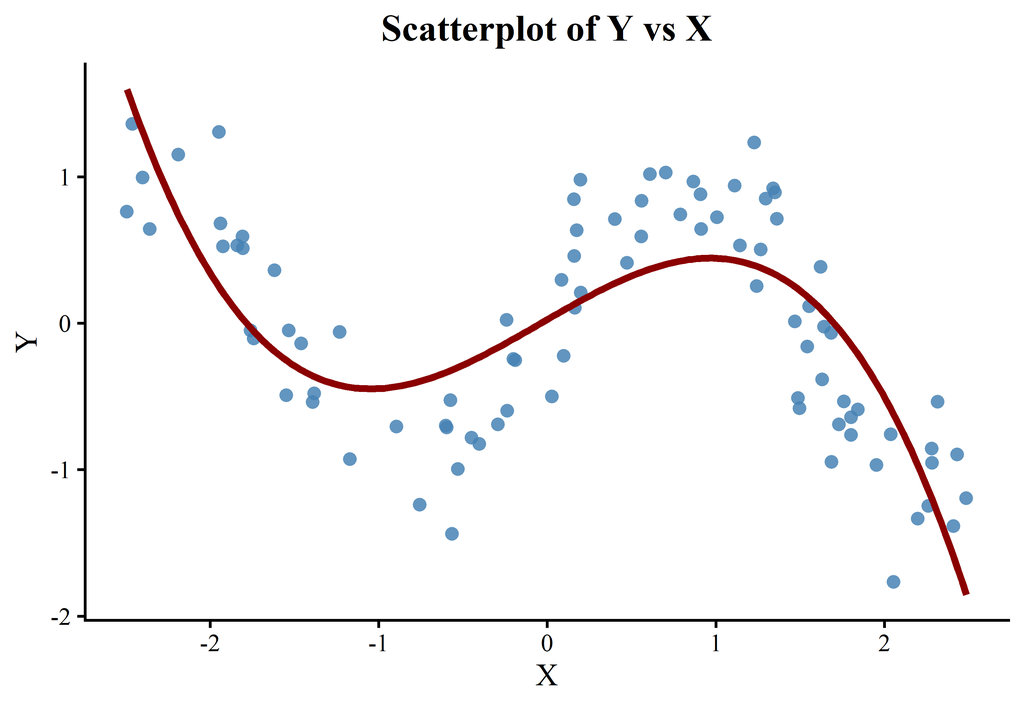

```r
xs <- data.frame(x = seq(min(x), (max(x)), length.out = 200))
xs$y <- predict(lm(y ~ x + I(x^2) + I(x^3), data = df), newdata = xs)

ggplot(df, aes(x, y)) +
  geom_point(
    color = "steelblue",
    size = 2.25,
    shape = 16,
    alpha = 0.85
  ) +
  geom_line(
    data = xs,
    aes(x, y),
    color = "darkred",
    linewidth = 1.25
  ) +
  labs(x = "X", y = "Y", title = "Scatterplot of Y vs X") +
  theme(
    axis.line = element_line(color = "black"),
    panel.grid = element_blank(),
    legend.position = c(0.85, 0.9)
  )
```

The scatterplot of $y$ against $x$ does not show a straight line. Instead it shows a clear S-shaped curve.

## Task 2 - observed correlations

Pearson’s correlation measures a linear relationship. Spearman’s correlation measures a trend that keeps the same direction. Neither measure fully describes the two changes seen in the plot.

```r
obs_pearson <- cor(x, y, method = "pearson")
obs_spearman <- cor(x, y, method = "spearman")
cat("n =", n, "\n")
cat("Observed Pearson r =", round(obs_pearson, 4), "\n")
cat("Observed Spearman rho =", round(obs_spearman, 4), "\n")
```

```
n = 90
Observed Pearson r = -0.3133
Observed Spearman rho = -0.3336
```

Both are only moderate weak negatives.

## Task 3 - pearson permutation test

I keep $x$ fixed and shuffle $y$ 4,999 times. The breaks the observed links between the two variables. For independent observations, the shuffle is valid under the null that $X$ and $Y$ are independent.

```r
set.seed(09190203)
perm_pearson <- vapply(seq_len(B), function(b)
  cor(x, sample(y), method = "pearson"), numeric(1))
pval_pearson <- (sum(abs(perm_pearson) >= abs(obs_pearson)) + 1) / (B + 1)
cat("Perm p (Pearson) =", round(pval_pearson, 4), "\n")
```

```
Perm p (Pearson) = 0.003
```

I compare the absolute observed correlation with the absolute correlations from the shuffled data:
$$p_{\text{Pearson}} = \frac{\#\{|r^*| \ge |r_{\text{obs}}|\} + 1}{B + 1}
= 0.003.$$

The result gives evidence against independence at the 5% level.

## Task 4 - spearman permutation test

I repeat the test with Spearman’s correlation, again comparing absolute values.

```r
set.seed(09190204)
perm_spearman <- vapply(seq_len(B), function(b)
  cor(x, sample(y), method = "spearman"), numeric(1))
pval_spearman <- (sum(abs(perm_spearman) >= abs(obs_spearman)) + 1) / (B + 1)
cat("Perm p (Spearman) =", round(pval_spearman, 4), "\n")
```

```
Perm p (Spearman) = 0.0024
```

The permutation p-value is 0.0024. This result also gives evidence against independence at the 5% level.

## Task 5 - comparing the two p-values to the visual impression

Both tests detect a relationship, which agrees with the plot. The small p-values do not tell us what shape that relationship has.

```r
lin_r2   <- summary(lm(y ~ x))$r.squared
cat("Straight line model R^2 =", round(lin_r2, 4))
```

```
Straight line model R^2 = 0.0982
```

The straight-line model has $R^2=0.0982$, so it explains about 10% of the variation in $y$. That leaves much of the pattern unexplained. The plot suggests that a curved fit would be more useful.

## Task 6 - is the permutation procedure the problem, or something else?

The permutation procedure is not the problem. Keeping $x$ fixed and shuffling $y$ simulates independence correctly. The statistic is the problem. Pearson captures only a linear trend, and Spearman only a monotone trend. The S-curve changes direction, so both are driven toward zero.

## Task 7 - a statistic that better captures the relationship

I chose the cubic model $y\sim x + x^2 + x^3$. Because the plot has two turns. Its $R^2$ measures how well the whole curve fits. The model uses all three terms together, so it can change direction as $x$ increases.

Here, $R^2$ has no sign and ranges from 0 to 1. I fit the model again after each shuffle of $y$, then compare the new values with the observed $R^2$.

```r
# Cubic R^2 (how much variance the S-curve explains)
set.seed(09190207)
cubic_r2 <- function(x, y)
  summary(lm(y ~ x + I(x^2) + I(x^3)))$r.squared
obs_r2 <- cubic_r2(x, y)
perm_r2 <- vapply(seq_len(B), function(b)
  cubic_r2(x, sample(y)), numeric(1))
pval_r2 <- (sum(perm_r2 >= obs_r2) + 1) / (B + 1)
cat("Cubic R^2 observed =",
    round(obs_r2, 4),
    " (linear R2 =",
    round(lin_r2, 4),
    ")\n")
cat("Perm p (cubic R^2) =", round(pval_r2, 4), "\n")
```

```
Cubic R^2 observed = 0.5802  (linear R2 = 0.0982 )
Perm p (cubic R^2) = 2e-04
```

The cubic fit explains about 58% of the variation, compared with about 10% for the straight line. Its p-value is 0.0002, the smallest value this calculation can give with 4,999 shuffles.

# Exercise 3 — Bootstrap uncertainty and the number of replicates

```r
set.seed(091903)
x <- na.omit(airquality$Wind)
n <- length(x)
```

## Task 1 - looking at the data

The wind speeds range from 1.7 to 20.7mph. The mean is about 10.0 mph, and the median is 9.7 mph. The standard deviation is about 3.5 mph.

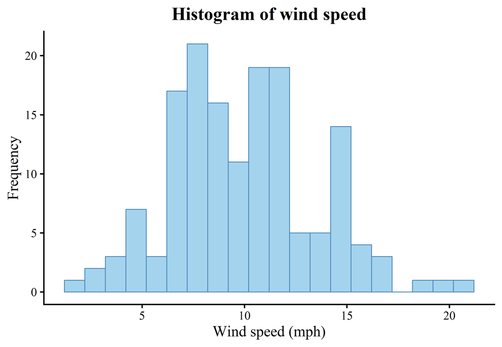

```r
summary(x)                 # Min Q1 Median Mean Q3 Max
sd(x)
var(x)
df <- data.frame(wind = x)

# histogram
ggplot(df, aes(x = wind)) +
  geom_histogram(
    bins = 20,
    fill = "lightskyblue2",
    color = "steelblue",
    linewidth = 0.3
  ) +
  labs(x = "Wind speed (mph)", y = "Frequency", title = "Histogram of wind speed") +
  theme(panel.grid = element_blank())
```

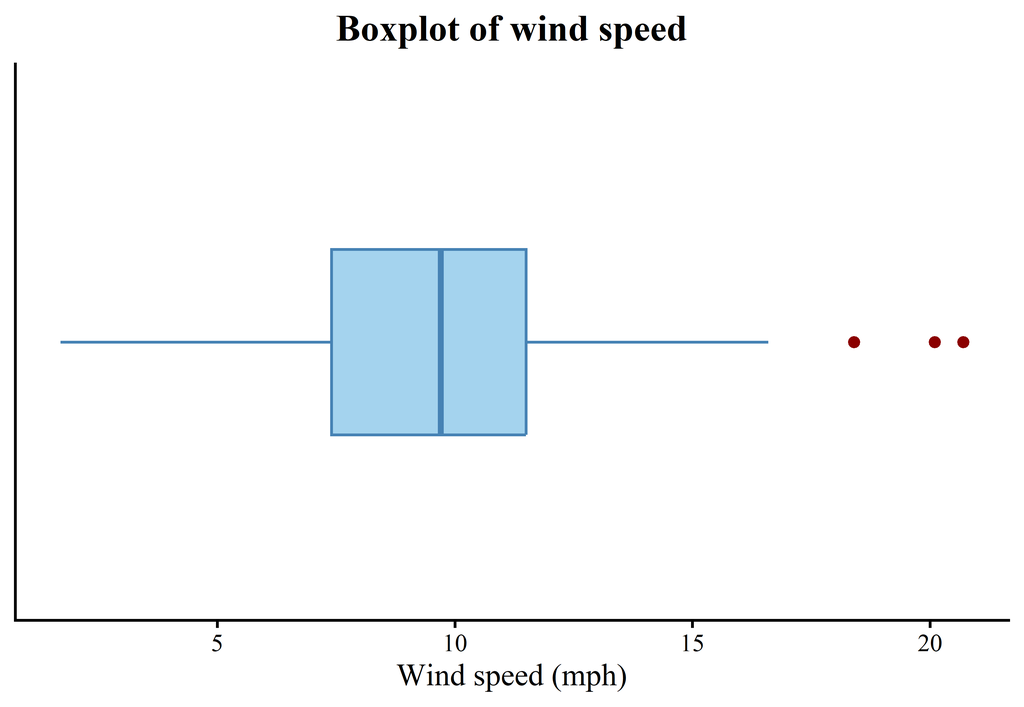

[output not shown]

```r
# horizontal boxplot
ggplot(df, aes(y = factor(1), x = wind)) +
  geom_boxplot(
    fill = "lightskyblue2",
    color = "steelblue",
    width = 0.4,
    outlier.color = "darkred"
  ) +
  labs(x = "Wind speed (mph)", y = NULL, title = "Boxplot of wind speed") +
  theme(
    panel.grid = element_blank(),
    axis.text.y = element_blank(),
    axis.ticks.y = element_blank()
  )
```

The histogram has a longer tail on the right. A few high wind speeds also appear beyond the upper whisker of the boxplot.

## Task 2 - sample median

```r
med_hat <- median(x)
cat("Sample median wind speed =", round(med_hat, 3), "\n")
```

```
Sample median wind speed = 9.7
```

The median wind speed in this sample is 9.7 mph.

I draw $n$ values from the observed sample with replacement. I then calculate the median of this new sample.

```r
boot_median <- function(x)
  median(sample(x, replace = TRUE))
boot_median(x)             # one bootstrap median
```

```
[1] 9.7
```

This bootstrap median is also 9.7 mph. It happens to match the original median.

## Task 4 - bootstrap SE for each $B$

I use the standard deviation of the $B$ bootstrap medians to estimate the standard error. The calculation is repeated with 100, 500, 2,000, and 10,000 resamples.

```r
boot_se <- function(x, B) {
  s <- replicate(B, boot_median(x))
  sd(s)                    # SE = sd of the B bootstrap medians
}
Bvals <- c(100, 500, 2000, 10000)
se_once <- sapply(Bvals, boot_se, x = x)
names(se_once) <- Bvals
print(round(se_once, 4))
```

```
   100    500   2000  10000
0.3555 0.3775 0.3657 0.3543
```

## Task 5 - repeat the whole calculation 20 times per $B$

I repeat the full standard error calculation 20 times for each value of $B$. These runs show how much the estimate changes because of random resampling.

```r
R   <- 20
res <- do.call(rbind, lapply(Bvals, function(b) {
  data.frame(B   = b,
             rep = seq_len(R),
             se  = replicate(R, boot_se(x, b)))
}))
```

## Task 6 - boxplot of the 20 SE estimates vs $B$

The boxplots compare the 20 standard error estimates from each setting.

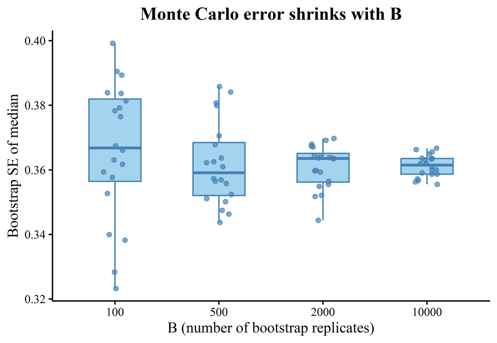

```r
res$B <- factor(res$B, levels = c(100, 500, 2000, 10000))
ggplot(res, aes(x = B, y = se)) +
  geom_boxplot(
    fill = "lightskyblue2",
    color = "steelblue",
    outlier.shape = NA,
    width = 0.5
  ) +
  geom_jitter(
    width = 0.12,
    size = 1.5,
    color = "steelblue",
    alpha = 0.7
  ) +
  labs(x = "B (number of bootstrap replicates)", y = "Bootstrap SE of median", title = "Monte Carlo error shrinks with B") +
  theme(panel.grid = element_blank())
```

The estimates vary less as $B$ increases, but their centers remain similar. More resamples make the calculation more stable. They do not reduce the sampling uncertainty of the median.

Monte Carlo error usually decreases at about the rate $1/\sqrt(B)$. Increasing $B$ from 100 to 10,000 reduces this simulation noise by about a factor of 10.

## Task 7 - statistical uncertainty vs. Monte Carlo error

Statistical uncertainty comes from the sample size $n$. It says how far our estimate is from the truth. No choice of $B$ removes it. Monte Carlo error is just the simulation noise from having only $B$ resamples, and that one does go away as $B$ grows.

## Task 8 - why more $B$ does not fix a small $n$

A larger $B$ only reuses the same observations more times. If the original sample misses part of the population’s pattern, the resamples will miss it too. We may get a very stable bootstrap result, but that result can still be a poor estimate of the true uncertainty.

## Task 9 - is $B=199$ enough to distinguish $p \approx 0.001$?

$B=199$ is too small for this purpose. A bootstrap p-value has a resolution of about $1/(B+1)$. For $B=199$, that is
$$\frac{1}{199+1}=0.005$$

With $B=999$, the minimum is 0.001, but estimates near this minimum are very noisy. With $B=9999$, the step size is 0.0001.

# Exercise 4 — Confidence intervals for the median wind speed

```r
theta_hat <- median(x)
B <- 10000
```

## Task 1 - B bootstrap replicates of the median

I generate 10,000 bootstrap medians and use the same set for all three confidence intervals.

```r
set.seed(092004)
boot_med <- replicate(B, median(sample(x, replace = TRUE)))
head(boot_med)
```

```
[1] 9.2 9.7 9.7 9.2 9.7 9.7
```

## Task 2 - normal interval

The normal interval uses the sample median and the bootstrap standard error. Its two limits are equally far from the sample median:
$$\hat{\theta}\pm1.96\hat{SE}_{boot}$$

```r
se_boot <- sd(boot_med)
z <- qnorm(0.975)
ci_normal <- theta_hat + c(-1, 1) * z * se_boot
```

## Task 3 - percentile interval

The percentile interval uses the 2.5th and 97.5th percentiles of the bootstrap medians. These percentiles give the lower and upper limits:
$$[q_{0.025}^*, q_{0.975}^*].$$

```r
ci_perc <- quantile(boot_med, c(0.025, 0.975))
```

## Task 4 - basic (pivot) interval

The basic interval reflects the bootstrap percentiles around the observed median. Its limits are:
$$[2\hat{\theta}-q_{0.975}^*, 2\hat{\theta}-q_{0.025}^*].$$

```r
q_lo <- quantile(boot_med, 0.025)
q_hi <- quantile(boot_med, 0.975)
ci_basic <- 2 * theta_hat - c(q_hi, q_lo)   # lower first: 2hat - q.975, 2hat - q.025

rbind(normal = ci_normal,
      percentile = ci_perc,
      basic = ci_basic)
cat("theta_hat =", theta_hat, " se_boot =", se_boot, "\n")
```

```
               2.5%   97.5%
normal     8.989598 10.4104
percentile 9.200000 10.3000
basic      9.100000 10.2000
theta_hat = 9.7  se_boot = 0.3624569
```

## Task 5 - where the basic interval comes from

The bootstrap replaces $\hat{\theta}-\theta$ by $\hat{\theta^*}-\hat{\theta}$. The central 95% interval for this pivot is
$$q^*_{0.025}-\hat{\theta} \le \hat{\theta}-\theta \le q^*_{0.975}-\hat{\theta}.$$
We solve for $\theta$. The right inequality gives
$$\theta\ge 2\hat{\theta}-q^*_{0.975}.$$
The left inequality gives
$$\theta\le 2\hat{\theta}-q^*_{0.025}.$$
The term $2\hat{\theta}$ appears for a simple reason. We move $\hat{\theta}$ across the inequalities, and two copies remain. The basic interval is the percentile interval mirrored around $\hat{\theta}$.

## Task 6 - plot the bootstrap distribution

The histogram code uses the same bootstrap medians as the interval calculations. The black line marks the sample median, and the red dashed lines mark the percentile limits.

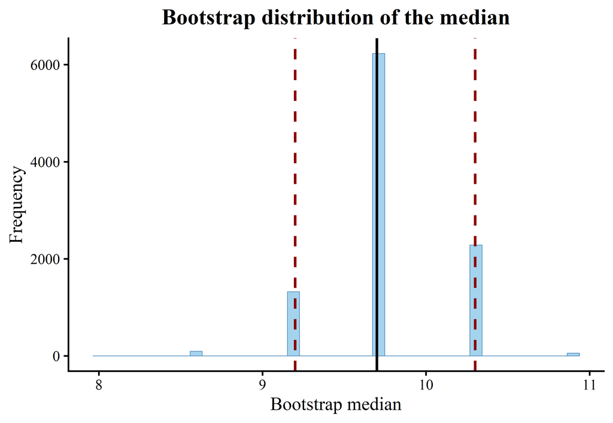

```r
df <- data.frame(b = boot_med)
ggplot(df, aes(x = b)) +
  geom_histogram(
    bins = 40,
    fill = "lightskyblue2",
    color = "steelblue",
    linewidth = 0.2
  ) +
  geom_vline(xintercept = theta_hat,
             color = "black",
             linewidth = 0.8) +
  geom_vline(
    xintercept = c(q_lo, q_hi),
    color = "darkred",
    linetype = "dashed",
    linewidth = 0.8
  ) +
  labs(x = "Bootstrap median", y = "Frequency", title = "Bootstrap distribution of the median") +
  theme(panel.grid = element_blank())
```

## Task 7 - comparing the three intervals

The normal interval is widest in these results and is centered on 9.7 mph. The percentile and basic intervals have the same width, but the basic interval is 0.1 mph lower. This shift comes from reflecting the percentile limits around the sample median.

The percentile and basic intervals match if both percentile limits are equally far from the observed median. The normal interval is also close when the bootstrap distribution is roughly normal and centered there. Symmetry alone does not make all three intervals equal.

## Task 8 - colleague claims the median is 10 mph

All three reported intervals contain 10 mph. We would not reject a population median of 10 mph using the tests that match these intervals. This conclusion is at the approximate two-sided 5% level. It does not prove that the population median is exactly 10 mph.

## Task 9 - “There is a 95% probability the true median is between my endpoints”

No. This is not the frequentist reading. The true $\theta$ is fixed. The interval is random. The “95%” describes the method. If we repeat the experiment many times, about 95% of the intervals cover $\theta$. For this one interval, $\theta$ is either in or out. There is no probability statement about $\theta$.

## Task 10 - a value just outside the interval

A value outside a 95% confidence interval is rejected by the two-sided 5% test that corresponds to that interval. This link requires the interval and the test to use the same method.

For continuous methods, a value just outside the interval often gives a p-value close to 0.05. Bootstrap distributions can be discrete, so the p-value may change in steps. The interval alone does not give an exact p-value.

# Exercise 5 — When the ordinary bootstrap fails

```r
set.seed(092005)
n <- 30
theta <- 0
x <- runif(n, theta, 1)
m_obs <- min(x)
m_obs
```

```
[1] 0.01102128
```

## Task 1 - B=5000 ordinary bootstrap minima

The sample contains 30 observations from $U(0,1)$. Its minimum is about 0.011. I draw 5,000 bootstrap samples and calculate the minimum of each sample.

```r
B <- 5000
boot_min <- replicate(B, min(sample(x, replace = TRUE)))
```

## Task 2 - $m_n^* \ge m_n$ for every bootstrap sample

```r
all(boot_min >= m_obs)          # TRUE, by construction: no resample can go below
```

```
[1] TRUE
```

```r
mean(boot_min == m_obs)         # fraction exactly at m_n ~= 1 - (1-1/n)^n ~= 0.64
```

```
[1] 0.6406
```

Every resample satisfies $m_n^* \ge m_n$. In this run, 64.06% of the bootstrap minima equal the observed minimum.

## Task 3 - bootstrap distribution of $m_n^* - m_n$

The histogram shows $m_n^* \ge m_n$. All differences are zero or positive. The large bar at zero comes from resamples that contain the original minimum.

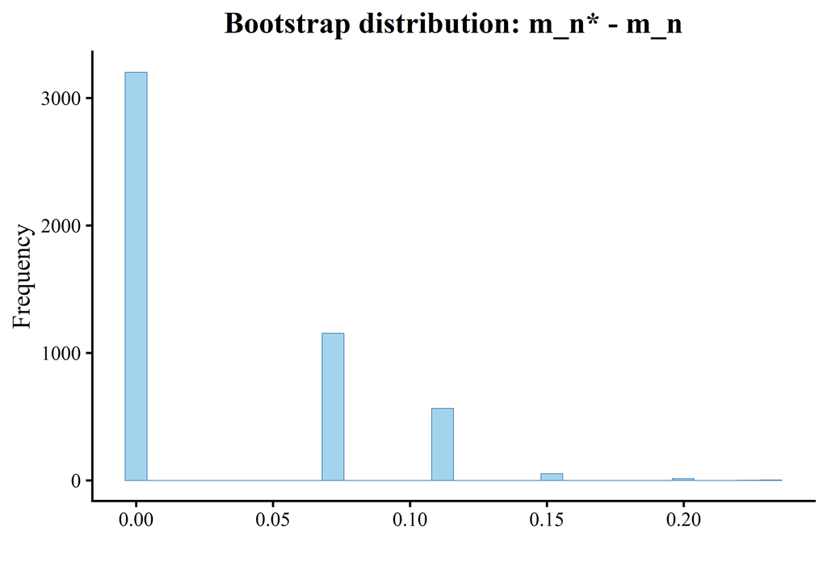

```r
ggplot(data.frame(d = boot_min - m_obs), aes(x = d)) +
  geom_histogram(
    bins = 30,
    fill = "lightskyblue2",
    color = "steelblue",
    linewidth = 0.2
  ) +
  labs(x = "", y = "Frequency", title = "Bootstrap distribution: m_n* - m_n") +
  theme(panel.grid = element_blank())
```

## Task 4 - 5000 fresh samples from the TRUE $U(0,1)$

I draw 5,000 fresh samples from $U(0,1)$ , with 30 values in each sample. I calculate each sample minimum to estimate its true sampling distribution.

```r
true_min <- replicate(B, min(runif(n, theta, 1)))
```

## Task 5 - compare to the true sampling distribution $m_n^{new} - \theta$

I compare the bootstrap errors $m_n^* \ge m_n$ with the fresh-sample errors $m_n^{new} - \theta$. The bootstrap errors have a large probability mass at zero. The true errors have a continuous distribution and no point mass at zero. This difference shows that the ordinary bootstrap misses an important feature of the sampling error.

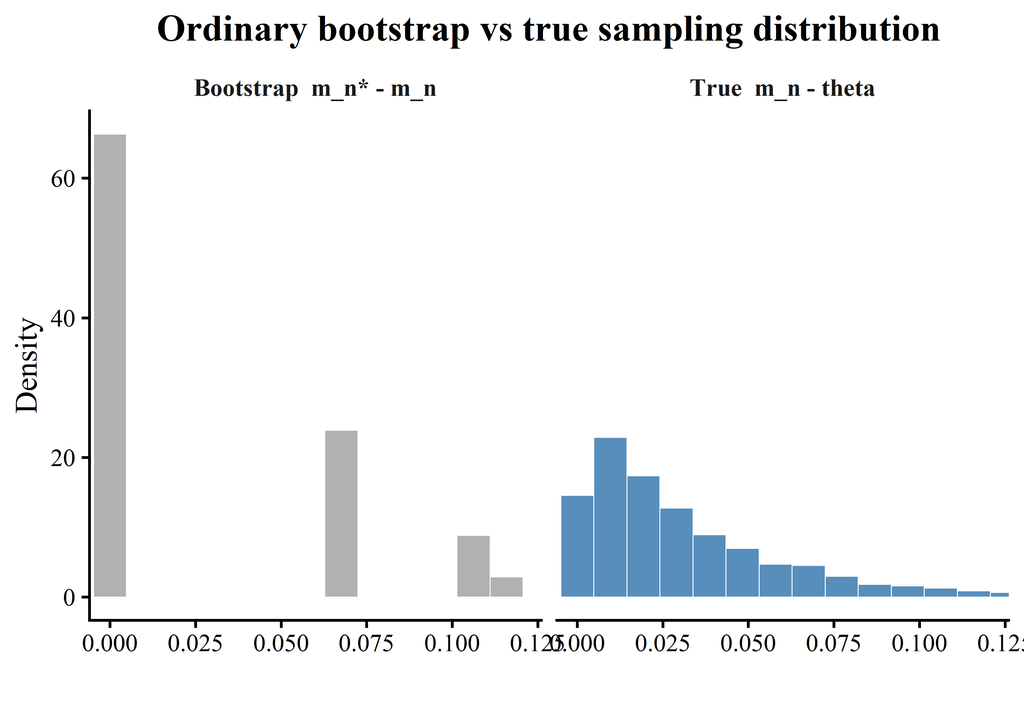

```r
cmp <- rbind(
  data.frame(diff = boot_min - m_obs, src = "Bootstrap  m_n* - m_n"),
  data.frame(diff = true_min - theta, src = "True  m_n - theta")
)
ggplot(cmp, aes(x = diff, fill = src)) +
  geom_histogram(
    aes(y = after_stat(density)),
    bins = 25,
    color = "white",
    linewidth = 0.2,
    alpha = 0.9,
    show.legend = FALSE
  ) +
  scale_fill_manual(values = c(
    "Bootstrap  m_n* - m_n" = "darkgrey",
    "True  m_n - theta" = "steelblue"
  )) +
  facet_wrap(~ src, nrow = 1) +
  coord_cartesian(xlim = c(0, 0.12)) +
  labs(x = "", y = "Density", title = "Ordinary bootstrap vs true sampling distribution") +
  theme(
    panel.grid = element_blank(),
    strip.background = element_blank(),
    strip.text = element_text(face = "bold")
  )
```

## Task 6 - why $F_n$ cannot reproduce the lower-endpoint uncertainty

The empirical distribution puts all mass on the observed values. The true lower endpoint $\theta$ lies below the smallest observed point. There is no data there. So no resample can draw a value below the observed minimum. The bootstrap cannot express the chance that $\theta$ is smaller.

## Task 7 - contrast with the sample mean

The mean uses all the observations, so many values contribute to its variation. For independent observations from the same distribution, a finite, nonzero variance gives an approximately normal sampling distribution in large samples. The ordinary bootstrap can estimate the mean’s uncertainty under these conditions.

The minimum depends on the single lowest value. In this uniform example, its uncertainty depends on the gap between that value and the lower endpoint. Resampling the observed values does not reproduce that gap correctly.

## Task 8 - another statistic where the ordinary bootstrap fails

The sample range, $\max(X_i)-\min(X_i)$, has the same kind of problem in this uniform example. A resample stays within the observed minimum and maximum, so its range cannot be larger than the observed range.

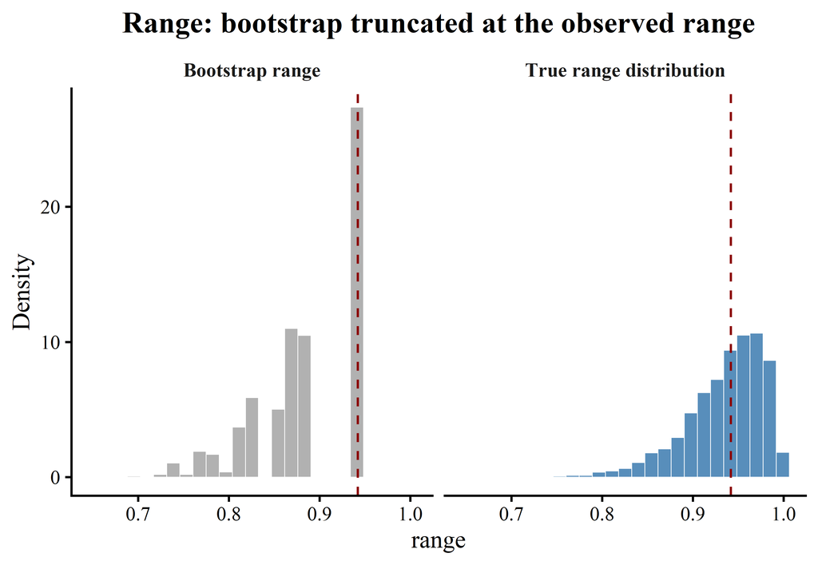

```r
boot_range <- replicate(B, {
  z <- sample(x, replace = TRUE)
  max(z) - min(z)
})
obs_range <- max(x) - min(x)
true_range <- replicate(B, {
  u <- runif(n)
  max(u) - min(u)
})

cmp2 <- rbind(
  data.frame(r = boot_range, src = "Bootstrap range"),
  data.frame(r = true_range, src = "True range distribution")
)
ggplot(cmp2, aes(x = r, fill = src)) +
  geom_histogram(
    aes(y = after_stat(density)),
    bins = 25,
    color = "white",
    linewidth = 0.2,
    alpha = 0.9,
    show.legend = FALSE
  ) +
  geom_vline(xintercept = obs_range,
             color = "darkred",
             linetype = "dashed") +
  scale_fill_manual(values = c(
    "Bootstrap range" = "darkgrey",
    "True range distribution" = "steelblue"
  )) +
  facet_wrap( ~ src, nrow = 1) +
  labs(x = "range", y = "Density", title = "Range: bootstrap truncated at the observed range") +
  theme(
    panel.grid = element_blank(),
    strip.background = element_blank(),
    strip.text = element_text(face = "bold")
  )
```

About 40% of resamples contain both original extremes and give exactly the same range. Fresh samples have continuous ranges and can fall on either side of the observed one. The repeated value and the upper limit in the bootstrap distribution give the wrong pattern of uncertainty. The sample maximum faces a similar problem at the upper endpoint.